# Project: TMDB movies Data Analysiec

- Introduction
- Data Wrangling
- Exploratory Data Analysis
- Conclusions

## Introduction

> **Tip**: We are going to look throw the data of TMDB movies trying to understand some basic visualization of the data and the relation between budget spent in the movie and the people's vote on it and the waht is type of movies was populer is the last years also we want to understand the features of the max revenue movies

```python
import pandas as pd
import numpy as np
import matplotlib.pyplot as plt
import matplotlib.figure as fig
%matplotlib inline
```

## Data Wrangling

> Preparing data and understand its features

### General Properties

```python
data=pd.read_csv('tmdb-movies.csv')
display(data.head())
```

|  | id | imdb_id | popularity | budget | revenue | original_title | cast | homepage | director | tagline | ... | overview | runtime | genres | production_companies | release_date | vote_count | vote_average | release_year | budget_adj | revenue_adj |
| --- | --- | --- | --- | --- | --- | --- | --- | --- | --- | --- | --- | --- | --- | --- | --- | --- | --- | --- | --- | --- | --- |
| 0 | 135397 | tt0369610 | 32.985763 | 150000000 | 1513528810 | Jurassic World | Chris Pratt\|Bryce Dallas Howard\|Irrfan Khan\|Vi... | http://www.jurassicworld.com/ | Colin Trevorrow | The park is open. | ... | Twenty-two years after the events of Jurassic ... | 124 | Action\|Adventure\|Science Fiction\|Thriller | Universal Studios\|Amblin Entertainment\|Legenda... | 6/9/15 | 5562 | 6.5 | 2015 | 1.379999e+08 | 1.392446e+09 |
| 1 | 76341 | tt1392190 | 28.419936 | 150000000 | 378436354 | Mad Max: Fury Road | Tom Hardy\|Charlize Theron\|Hugh Keays-Byrne\|Nic... | http://www.madmaxmovie.com/ | George Miller | What a Lovely Day. | ... | An apocalyptic story set in the furthest reach... | 120 | Action\|Adventure\|Science Fiction\|Thriller | Village Roadshow Pictures\|Kennedy Miller Produ... | 5/13/15 | 6185 | 7.1 | 2015 | 1.379999e+08 | 3.481613e+08 |
| 2 | 262500 | tt2908446 | 13.112507 | 110000000 | 295238201 | Insurgent | Shailene Woodley\|Theo James\|Kate Winslet\|Ansel... | http://www.thedivergentseries.movie/#insurgent | Robert Schwentke | One Choice Can Destroy You | ... | Beatrice Prior must confront her inner demons ... | 119 | Adventure\|Science Fiction\|Thriller | Summit Entertainment\|Mandeville Films\|Red Wago... | 3/18/15 | 2480 | 6.3 | 2015 | 1.012000e+08 | 2.716190e+08 |
| 3 | 140607 | tt2488496 | 11.173104 | 200000000 | 2068178225 | Star Wars: The Force Awakens | Harrison Ford\|Mark Hamill\|Carrie Fisher\|Adam D... | http://www.starwars.com/films/star-wars-episod... | J.J. Abrams | Every generation has a story. | ... | Thirty years after defeating the Galactic Empi... | 136 | Action\|Adventure\|Science Fiction\|Fantasy | Lucasfilm\|Truenorth Productions\|Bad Robot | 12/15/15 | 5292 | 7.5 | 2015 | 1.839999e+08 | 1.902723e+09 |
| 4 | 168259 | tt2820852 | 9.335014 | 190000000 | 1506249360 | Furious 7 | Vin Diesel\|Paul Walker\|Jason Statham\|Michelle ... | http://www.furious7.com/ | James Wan | Vengeance Hits Home | ... | Deckard Shaw seeks revenge against Dominic Tor... | 137 | Action\|Crime\|Thriller | Universal Pictures\|Original Film\|Media Rights ... | 4/1/15 | 2947 | 7.3 | 2015 | 1.747999e+08 | 1.385749e+09 |

5 rows × 21 columns

```python
data.shape
```

```
(10866, 21)
```

```python
data.info()
```

```
<class 'pandas.core.frame.DataFrame'>
RangeIndex: 10866 entries, 0 to 10865
Data columns (total 21 columns):
id                      10866 non-null int64
imdb_id                 10856 non-null object
popularity              10866 non-null float64
budget                  10866 non-null int64
revenue                 10866 non-null int64
original_title          10866 non-null object
cast                    10790 non-null object
homepage                2936 non-null object
director                10822 non-null object
tagline                 8042 non-null object
keywords                9373 non-null object
overview                10862 non-null object
runtime                 10866 non-null int64
genres                  10843 non-null object
production_companies    9836 non-null object
release_date            10866 non-null object
vote_count              10866 non-null int64
vote_average            10866 non-null float64
release_year            10866 non-null int64
budget_adj              10866 non-null float64
revenue_adj             10866 non-null float64
dtypes: float64(4), int64(6), object(11)
memory usage: 1.7+ MB
```

> Cleaning any missing data and handling missing values

```python
data.drop(['id','imdb_id','homepage','tagline','keywords','production_companies'],axis=1,inplace=True)
```

```python
data.dropna(inplace=True)
```

```python
data0=data[data['budget']!=0]
budgetmean=data0['budget'].mean()
data['budget']=data['budget'].replace(0,budgetmean)
```

```python
data0=data[data['revenue']!=0]
revmean=data0['revenue'].mean()
data['revenue']=data['revenue'].replace(0,revmean)
```

> Some statistics of the data

```python
data.describe()
```

|  | popularity | budget | revenue | runtime | vote_count | vote_average | release_year | budget_adj | revenue_adj |
| --- | --- | --- | --- | --- | --- | --- | --- | --- | --- |
| count | 10730.000000 | 1.073000e+04 | 1.073000e+04 | 10730.000000 | 10730.000000 | 10730.000000 | 10730.000000 | 1.073000e+04 | 1.073000e+04 |
| mean | 0.652688 | 3.082808e+07 | 8.932157e+07 | 102.477633 | 219.840913 | 5.964809 | 2001.258621 | 1.776975e+07 | 5.201117e+07 |
| std | 1.004834 | 2.697832e+07 | 1.089370e+08 | 30.479401 | 578.836513 | 0.930264 | 12.820336 | 3.446726e+07 | 1.454310e+08 |
| min | 0.000188 | 1.000000e+00 | 2.000000e+00 | 0.000000 | 10.000000 | 1.500000 | 1960.000000 | 0.000000e+00 | 0.000000e+00 |
| 25% | 0.210766 | 1.900000e+07 | 4.020795e+07 | 90.000000 | 17.000000 | 5.400000 | 1995.000000 | 0.000000e+00 | 0.000000e+00 |
| 50% | 0.387247 | 3.082808e+07 | 8.932157e+07 | 99.000000 | 39.000000 | 6.000000 | 2006.000000 | 0.000000e+00 | 0.000000e+00 |
| 75% | 0.721158 | 3.082808e+07 | 8.932157e+07 | 112.000000 | 148.000000 | 6.600000 | 2011.000000 | 2.112691e+07 | 3.470565e+07 |
| max | 32.985763 | 4.250000e+08 | 2.781506e+09 | 900.000000 | 9767.000000 | 9.200000 | 2015.000000 | 4.250000e+08 | 2.827124e+09 |

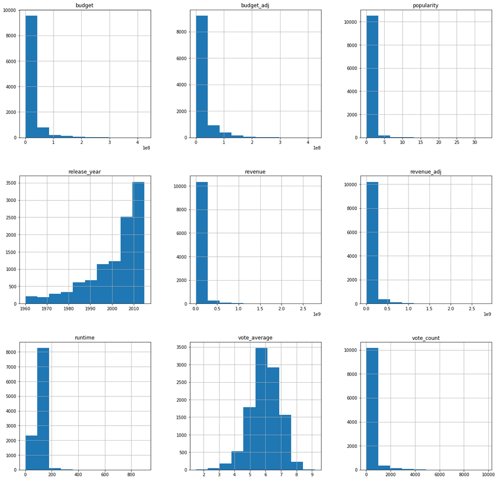

```python
data.hist(figsize=(20,20));
```

```python
data.info()
```

```
<class 'pandas.core.frame.DataFrame'>
Int64Index: 10730 entries, 0 to 10865
Data columns (total 15 columns):
popularity        10730 non-null float64
budget            10730 non-null float64
revenue           10730 non-null float64
original_title    10730 non-null object
cast              10730 non-null object
director          10730 non-null object
overview          10730 non-null object
runtime           10730 non-null int64
genres            10730 non-null object
release_date      10730 non-null object
vote_count        10730 non-null int64
vote_average      10730 non-null float64
release_year      10730 non-null int64
budget_adj        10730 non-null float64
revenue_adj       10730 non-null float64
dtypes: float64(6), int64(3), object(6)
memory usage: 1.3+ MB
```

## Exploratory Data Analysis

### Q2) What is relation between movie budget and reviews?

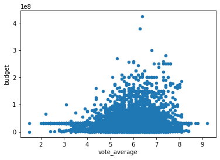

```python
data.plot(x='vote_average',y='budget',kind='scatter');
```

> The budget of the max vote

```python
maxvote=data.vote_average.max()
votemaxbud=data[data['vote_average']==maxvote].groupby('vote_average').budget.value_counts()
votemaxbud
```

```
vote_average  budget
9.2           3.082808e+07    1
Name: budget, dtype: int64
```

> The vote of the max budget

```python
maxbudget=data.budget.max()
budmaxvot=data[data['budget']==maxbudget].groupby('budget').vote_average.value_counts()
budmaxvot
```

```
budget       vote_average
425000000.0  6.4             1
Name: vote_average, dtype: int64
```

### Q2) Which genres are most popular from year to year?

> showing The most popular movies every year

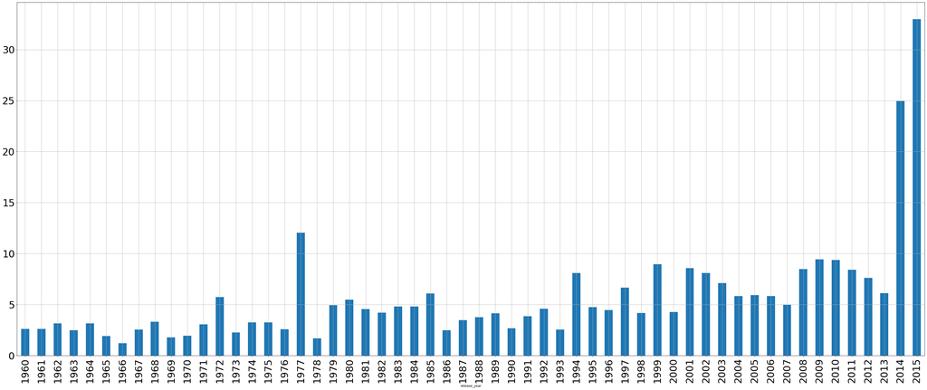

```python
mostpopinyear=data.groupby('release_year').popularity.max()
mostpopinyear.plot(kind='bar',figsize=(50,20),fontsize=30,grid=True);
```

```python
genres=pd.DataFrame(columns=data.columns)
for c in range(0,mostpopinyear.shape[0]):
    temp=data[(data['release_year']==mostpopinyear.index[c])&(data['popularity']==mostpopinyear.values[c])]
    genres=genres.append(temp, ignore_index=True)
genres.head()
```

|  | popularity | budget | revenue | original_title | cast | director | overview | runtime | genres | release_date | vote_count | vote_average | release_year | budget_adj | revenue_adj |
| --- | --- | --- | --- | --- | --- | --- | --- | --- | --- | --- | --- | --- | --- | --- | --- |
| 0 | 2.610362 | 806948.0 | 32000000.0 | Psycho | Anthony Perkins\|Vera Miles\|John Gavin\|Janet Le... | Alfred Hitchcock | When larcenous real estate clerk Marion Crane ... | 109 | Drama\|Horror\|Thriller | 8/14/60 | 1180 | 8.0 | 1960 | 5.949601e+06 | 2.359350e+08 |
| 1 | 2.631987 | 4000000.0 | 215880014.0 | One Hundred and One Dalmatians | Rod Taylor\|J. Pat O'Malley\|Betty Lou Gerson\|Ma... | Clyde Geronimi\|Hamilton Luske\|Wolfgang Reitherman | When a litter of dalmatian puppies are abducte... | 79 | Adventure\|Animation\|Comedy\|Family | 1/25/61 | 913 | 6.6 | 1961 | 2.917944e+07 | 1.574815e+09 |
| 2 | 3.170651 | 1100000.0 | 59600000.0 | Dr. No | Sean Connery\|Ursula Andress\|Joseph Wiseman\|Jac... | Terence Young | In the film that launched the James Bond saga,... | 110 | Adventure\|Action\|Thriller | 10/4/62 | 560 | 6.7 | 1962 | 7.929294e+06 | 4.296236e+08 |
| 3 | 2.508235 | 2500000.0 | 78898765.0 | From Russia With Love | Sean Connery\|Daniela Bianchi\|Lotte Lenya\|Rober... | Terence Young | Agent 007 is back in the second installment of... | 115 | Action\|Thriller\|Adventure | 10/11/63 | 458 | 6.7 | 1963 | 1.780045e+07 | 5.617734e+08 |
| 4 | 3.153791 | 3500000.0 | 124900000.0 | Goldfinger | Sean Connery\|Honor Blackman\|Gert FrÃ¶be\|Shirle... | Guy Hamilton | Special agent 007 (Sean Connery) comes face to... | 110 | Adventure\|Action\|Thriller | 9/17/64 | 602 | 7.0 | 1964 | 2.460594e+07 | 8.780804e+08 |

> Assuming that the first genre of every movie is the main genre of the movie and splitting the data accourdingly

```python
genres['genres']=genres['genres'].apply(lambda x:x.split('|')[0])
genres['genres'].value_counts()
```

```
Adventure          17
Action             10
Drama               6
Science Fiction     5
Animation           5
Crime               3
Horror              2
Romance             2
Comedy              2
Family              1
Fantasy             1
Music               1
Thriller            1
Name: genres, dtype: int64
```

> plotting a the movie vs release date

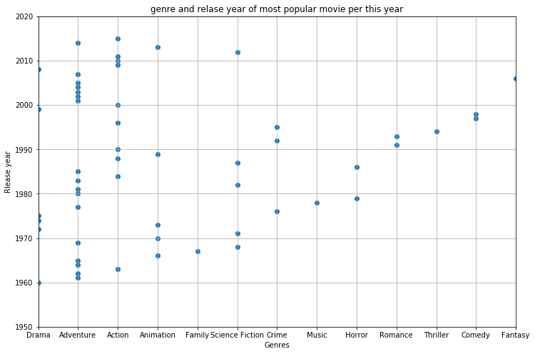

```python
plt.rcParams["figure.figsize"] = (12,8)
plt.scatter(genres['genres'],genres['release_year']);
plt.axis(['Drama','Fantasy',1950, 2020])
plt.xlabel('Genres')
plt.ylabel('Rlease year')
plt.title('genre and relase year of most popular movie per this year')
plt.grid(True)
```

### What kinds of properties are associated with movies that have high revenues?

> getting the highest revenue movies

```python
highrev=data.nlargest(500,['revenue'],keep='last')
highrev.info()
```

```
<class 'pandas.core.frame.DataFrame'>
Int64Index: 500 entries, 1386 to 2878
Data columns (total 15 columns):
popularity        500 non-null float64
budget            500 non-null float64
revenue           500 non-null float64
original_title    500 non-null object
cast              500 non-null object
director          500 non-null object
overview          500 non-null object
runtime           500 non-null int64
genres            500 non-null object
release_date      500 non-null object
vote_count        500 non-null int64
vote_average      500 non-null float64
release_year      500 non-null int64
budget_adj        500 non-null float64
revenue_adj       500 non-null float64
dtypes: float64(6), int64(3), object(6)
memory usage: 62.5+ KB
```

> The relation between the revenue of the movie and its vote

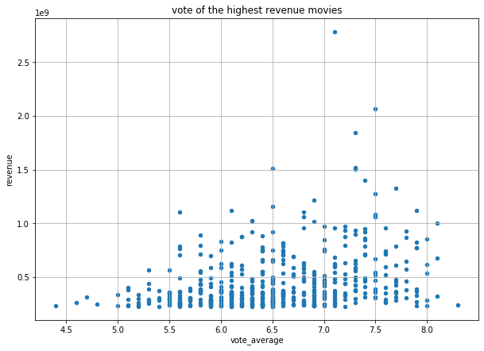

```python
highrev.plot(x='vote_average',y='revenue',kind='scatter',grid=True,figsize=(10,7),title="vote of the highest revenue movies");
```

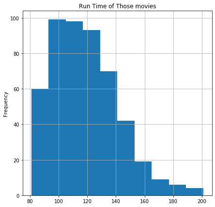

```python
highrev.runtime.plot(kind='hist',grid=True,figsize=(7,7),title="Run Time of Those movies");
```

> visualising the number of same genres that is included in the highest revenue movies

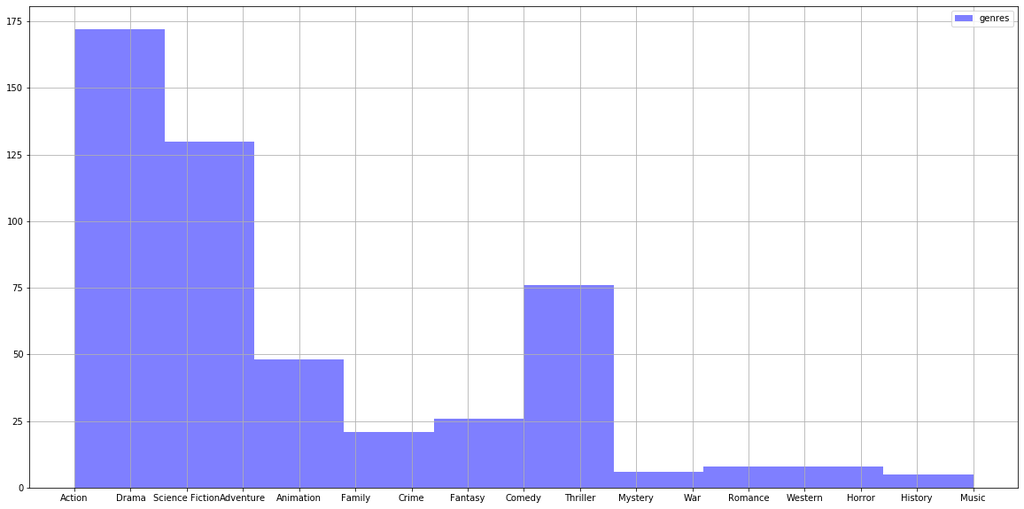

```python
highrev['genres']=highrev['genres'].apply(lambda x:x.split('|')[0])
highrev.genres.hist(alpha=0.5,figsize=(20,10),color='blue',label='genres');
plt.legend();
```

> Trying to understand the relation between the budget spent and the revune gained

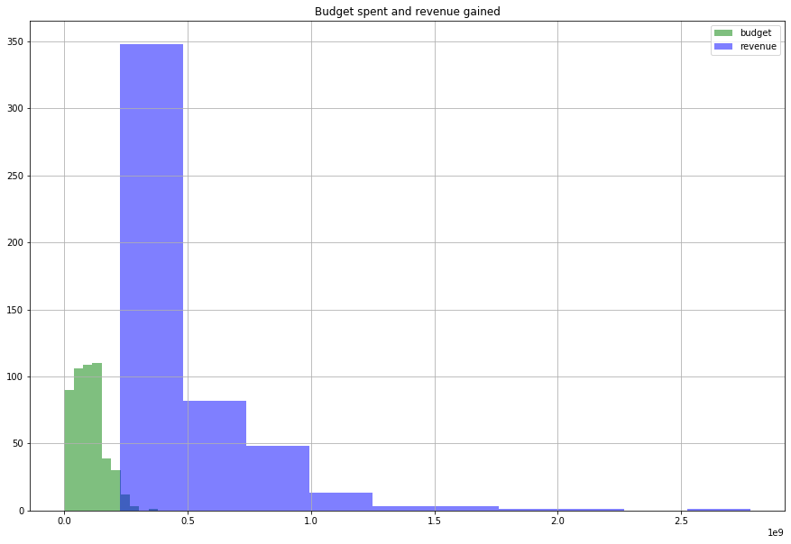

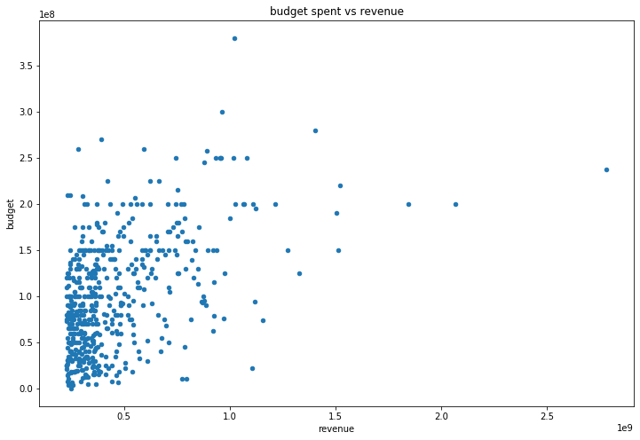

```python
highrev.budget.hist(alpha=0.5,figsize=(15,10),color='green',label='budget');
highrev.revenue.hist(alpha=0.5,figsize=(15,10),color='blue',label='revenue');
plt.title('Budget spent and revenue gained')
plt.legend();
highrev.plot(x='revenue',y='budget',kind='scatter',title='budget spent vs revenue');
```

## Conclusions

> From question one we examined the budget spent and the vote the movie got to understand if their is any correlation which seemed to be none

> question 2 we figured out the genre of the most populer movie each year and the most frequent genre was adventure

> question we tried to understand the relation between the revenue gained of each movie and its vote,runtime,budget and genre